# Class 1

B. Kadiyala

2/11/2020

## Statistics and Predictive Analytics

Download and install R and Rstudio if you have not already done so.

```
# https://www.rstudio.com
# https://www.r-project.org
```

Rstudio environment: starting in the upper right, clockwise: # Environment pane: shows which object are in memory. # Plot pane: displays plots created with code. # Console: allows you to run code by pressing return; code is not saved. # Source pane: contains documents you are working on (like this script).

### Install dplyr and ggplot2 packages:

Tools -> Install Packages

### Cheatsheets

Help -> Cheatsheets

### R document types: scripts, notebooks, RMarkdown, etc.

- Scripts are just text files. Email them to collaborators.
- The hashtag indicates a comment that R should ignore.
- Run individual lines in the script by pressing control-return.
- You can also select a portion of a script to run it.

### Projects! (for file management). Create IS-6489 project.

```
# File -> New Project
```

### Objects in R

The basis of R programming consists in assigning values to objects and manipulating those objects. Most simply, R is just a calculator

```r
2 + 3
```

```
## [1] 5
```

That calculation runs in the console. But we can save the value in an object which is stored in memory. To do so we use the assignment operator, <-.

```r
x <- 2 + 3
x
```

```
## [1] 5
```

```r
x + x
```

```
## [1] 10
```

There is always more than one way to do things in R! We can use a built in function also.

```r
sum(x, x)
```

```
## [1] 10
```

```r
x * x
```

```
## [1] 25
```

```r
prod(x, x)
```

```
## [1] 25
```

```r
x^2
```

```
## [1] 25
```

```r
y <- x + x
```

Question: What is the value of y?

### Getting data into R

#### 1. Built in data

```r
data(mtcars)
```

`mtcars` is a multidimensional data structure known as a dataframe. A dataframe is similar to a spreadsheet, with rows and columns, where each column has the same number of rows

#### 2. Import with code

Load csv into your local folder (supply the path to the file if the file is not in your working directory)

```r
d <- read.csv("day.csv")
```

Here we have read in day.csv with the read.csv() command, and have stored it as an object, d, which is a dataframe.

How do you know what your working directory is?

```r
getwd()
```

```
## [1] "/Users/eduardo.gomez/Documents/GoogleDrive/Education/UofU/2019 Spring/IS6489_Stats_Predictive_Analytics/rStudio-classes"
```

#### 3. Import with Rstudio.

Use Rstudio’s “import dataset” button to browse for data on your computer. This is a tab in the environment pane, upper right.

#### 4. Retrieve from the web.

```r
a <- read.csv("http://archive.ics.uci.edu/ml/machine-learning-databases/abalone/abalone.data",
              header = F)
```

### Day.csv

The day.csv comes from https://archive.ics.uci.edu/ml/datasets/bike+sharing+dataset#.

Bike-sharing rental process is highly correlated to the environmental and seasonal settings. For instance, weather conditions, precipitation, day of week, season, hour of the day, etc. can affect the rental behaviors. The core data set is related to  
the two-year historical log corresponding to years 2011 and 2012 from Capital Bikeshare system, Washington D.C., USA which is publicly available in http://capitalbikeshare.com/system-data. We aggregated the data on two hourly and daily basis and then extracted and added the corresponding weather and seasonal information. Weather information are extracted from http://www.freemeteo.com.

```r
d <- read_csv("day.csv")
glimpse(d)
```

```
## Observations: 731
## Variables: 17
## $ X1         <dbl> 1, 2, 3, 4, 5, 6, 7, 8, 9, 10, 11, 12, 13, 14, 15, 16…
## $ instant    <dbl> 1, 2, 3, 4, 5, 6, 7, 8, 9, 10, 11, 12, 13, 14, 15, 16…
## $ dteday     <date> 2011-01-01, 2011-01-02, 2011-01-03, 2011-01-04, 2011…
## $ season     <dbl> 1, 1, 1, 1, 1, 1, 1, 1, 1, 1, 1, 1, 1, 1, 1, 1, 1, 1,…
## $ yr         <dbl> 0, 0, 0, 0, 0, 0, 0, 0, 0, 0, 0, 0, 0, 0, 0, 0, 0, 0,…
## $ mnth       <dbl> 1, 1, 1, 1, 1, 1, 1, 1, 1, 1, 1, 1, 1, 1, 1, 1, 1, 1,…
## $ holiday    <dbl> 0, 0, 0, 0, 0, 0, 0, 0, 0, 0, 0, 0, 0, 0, 0, 0, 1, 0,…
## $ weekday    <dbl> 6, 0, 1, 2, 3, 4, 5, 6, 0, 1, 2, 3, 4, 5, 6, 0, 1, 2,…
## $ workingday <dbl> 0, 0, 1, 1, 1, 1, 1, 0, 0, 1, 1, 1, 1, 1, 0, 0, 0, 1,…
## $ weathersit <dbl> 2, 2, 1, 1, 1, 1, 2, 2, 1, 1, 2, 1, 1, 1, 2, 1, 2, 2,…
## $ temp       <dbl> 0.3441670, 0.3634780, 0.1963640, 0.2000000, 0.2269570…
## $ atemp      <dbl> 0.3636250, 0.3537390, 0.1894050, 0.2121220, 0.2292700…
## $ hum        <dbl> 0.805833, 0.696087, 0.437273, 0.590435, 0.436957, 0.5…
## $ windspeed  <dbl> 0.1604460, 0.2485390, 0.2483090, 0.1602960, 0.1869000…
## $ casual     <dbl> 331, 131, 120, 108, 82, 88, 148, 68, 54, 41, 43, 25, …
## $ registered <dbl> 654, 670, 1229, 1454, 1518, 1518, 1362, 891, 768, 128…
## $ cnt        <dbl> 985, 801, 1349, 1562, 1600, 1606, 1510, 959, 822, 132…
```

```r
d %>%
  group_by(season) %>%
  summarize(mean = mean(cnt),
            median = median(cnt),
            perc_60 = quantile(cnt, probs = c(.6)))
```

```
## # A tibble: 4 x 4
##   season  mean median perc_60
##    <dbl> <dbl>  <dbl>   <dbl>
## 1      1 2604.  2209    2729
## 2      2 4992.  4942.   5449
## 3      3 5644.  5354.   6045
## 4      4 4728.  4634.   5140.
```

```r
quantile(d$cnt)
```

```
##   0%  25%  50%  75% 100%
##   22 3152 4548 5956 8714
```

```r
quantile(d$cnt, probs = c(.5, .6, .7))
```

```
##  50%  60%  70%
## 4548 4968 5531
```

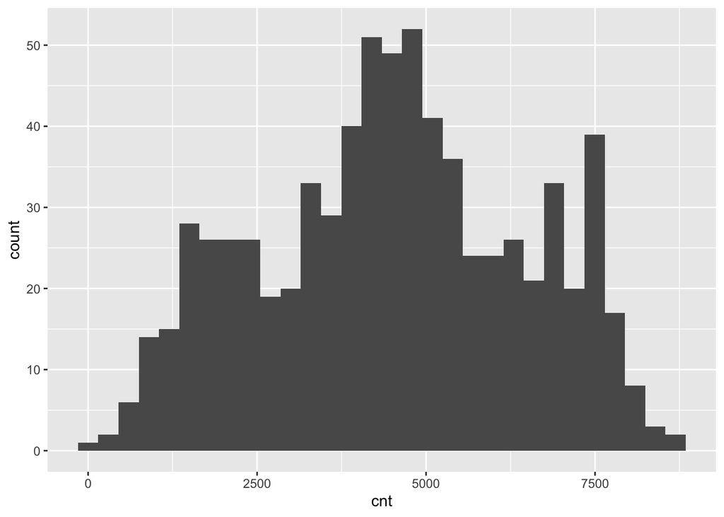

```r
ggplot(d, aes(cnt))+
  geom_histogram()
```

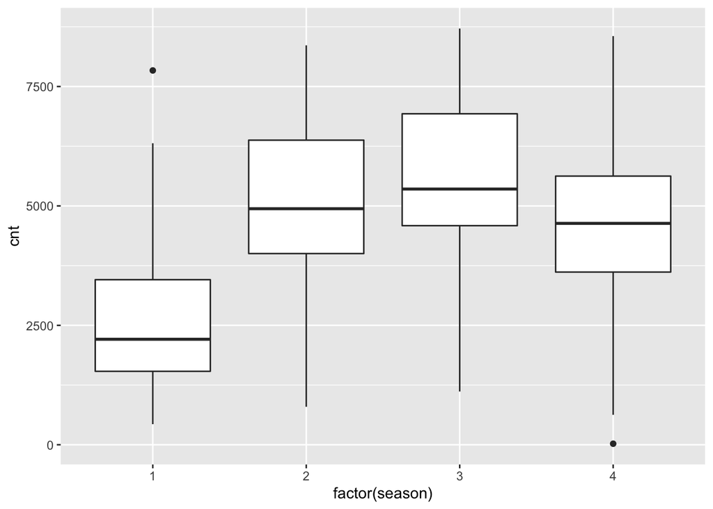

```r
ggplot(d, aes(x = factor(season), y = cnt))+
  geom_boxplot()
```

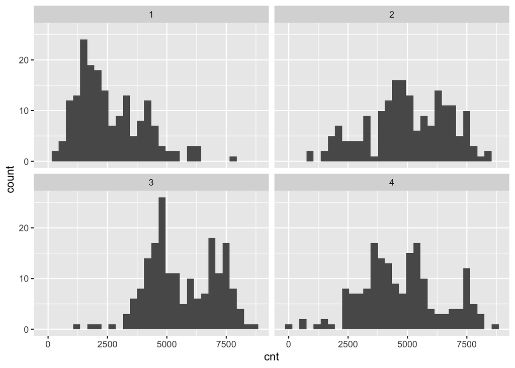

```r
ggplot(d, aes(cnt))+
  geom_histogram()+
  facet_wrap(~season)
```

```r
view(d)
```